# Sim_HW4

Alex Blohm

10/23/2019

Libs

```r
library(tidyverse)
```

# 1. Chapter 18, Exercise 4.

4. Consider the discrete random variable with pmf given by: P(X=1)=0.1, P(X=2)=0.3, P(X=5)=0.6.

## Plot the cdf for this random variable.

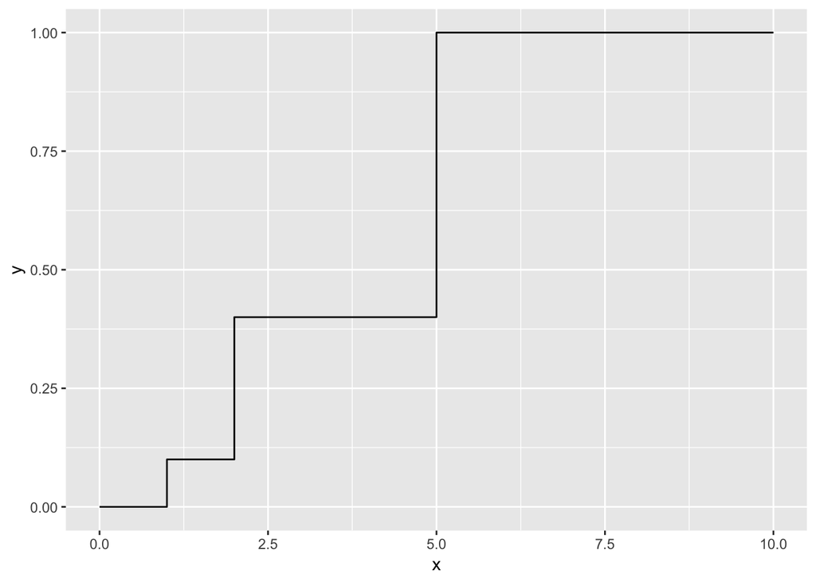

```r
data1 <- data.frame(
x <- c(0, 1, 2, 5, 10),
y <- c(0, .1, .4, 1, 1)
)
ggplot(data1, aes(x=x, y=y)) + geom_step()
```

## Write a program to simulate a random variable with this distribution, using the built-in function runif(1).

```r
funk <- function(){
value <- runif(1)
out <- NA
if (value > 0.4) {out = 5}
else if (value > 0.1 & value <= .4) {out = 2}
else {out = 1}
return(out)
}
funk()
```

```
## [1] 5
```

# 2. (GRAD ONLY) Chapter 18, Exercise 11a.

11. (a).

Here is some code for simulating a discrete random variable Y . What is the probability mass function (pmf) of Y ? Y.sim <- function() { U <- runif(1) Y <- 1 while (U > 1 - 1/(1+Y)) { Y <- Y + 1 } return(Y) } Let N be the number of times you go around the while loop when Y.sim() is called. What is EN and thus what is the expected time taken for this function to run?

If Y = 1
$$U > 1 - \frac{1}{1+1}$$
$$U > 1 - \frac{1}{2}$$
$$U >\frac{1}{2}$$
$$P(Y=1) >\frac{1}{2}$$

If Y = 2
$$U > 1 - \frac{1}{1+1}$$
$$U > 1 - \frac{1}{3}$$
$$U >\frac{2}{3}$$
$$P(Y=2) >\frac{1}{3}$$

If Y = 3
$$U > 1 - \frac{1}{1+3}$$
$$U > 1 - \frac{1}{4}$$
$$U >\frac{3}{4}$$
$$P(Y=3) >\frac{1}{4}$$

PMF of Y is $\frac{1}{1 + Y}$

```r
Y.sim <- function() {
  U <- runif(1)
  Y <- 1
  while (U > 1 - 1/(1+Y)) {
Y <- Y + 1
}
return(Y)
}

SIM <- replicate(Y.sim(), n = 100000)
mean(SIM)
```

```
## [1] 14.57758
```

Re-running this gives me very different values each time. We know that the harmonic series does not converge (but the sequence does), and this is a form of the harmonic series, therefore it does not converge. So E(Y) does not exist, because this is not a valid CDF (i.e. the infinite sum does not converge).

# 3. Chapter 18, Exercise 12.

12. People arrive at a shoe store at random. Each person then looks at a random number of shoes before deciding which to buy.

## (a).

Let N be the number of people that arrive in an hour. Given that EN = 10, what would be a good distribution for N?

Poisson($\lambda = 10$)

## (b).

Customer i tries on Xi pairs of shoes they do not like before finding a pair they like and then purchase (Xi ∈ {0, 1, . . .}). Suppose that the chance they like a given pair of shoes is 0.8, independently of the other shoes they have looked at. What is the distribution of Xi?

This sounds Geometric(p = .80) Note that this only counts shoes that are tried on, but NOT purchased.

## (c).

Let Y be the total number of shoes that have been tried on, excluding those purchased. Supposing that each customer acts independently of other customers, give an expression for Y in terms of N and the Xi, then write functions for simulating N, Xi, and Y.

$$Y = \sum_{i=1}^{N} X_i$$

```r
Shoes_Tried_NOT_Bought<- function(){
N = rpois(n=1, lambda = 10)
X <- rgeom(n = N, p = .8)
Y <- sum(X)
out <- list(N = N, X = X, Y = Y)
return(out)
}
Shoes_Tried_NOT_Bought()
```

```
## $N
## [1] 8
##
## $X
## [1] 1 0 0 0 0 1 0 1
##
## $Y
## [1] 3
```

## (d).

What is P(Y = 0)?

Cases for number of people in the store Case 1, if 0 people come into the store:
$$p(x = 0, λ = 10) = \frac{e^{-10} 10^0}{0!} * 1$$

Times 1 because there is a 100% chance of these zero people putting back shoes.

Case 2, if 1 person comes into the store:
$$p(x = 1, λ = 10) = \frac{e^{-10} 10^1}{1!} * (.80)$$
Times .80 because geometric prob.

Case 3, if 2 people come into the store:
$$p(x = 2, λ = 10) = \frac{e^{-10} 10^2}{2!} * (.80)^2$$

Case n, if n people come into the store:
$$p(x = n, λ = 10) = \frac{e^{-10} 10^n}{n!} * (.80)^n$$

So the theoretical probability is the sum of all the cases:
$$p(Y = 0) = \sum_{j= 0}^{\infty} \frac{e^{-10} 10^j}{j!} * (.80)^j$$

```r
individual_case <- function(j){
  (exp(-10)*10^j)/(factorial(j)) * (.8^j)
}
Theoretical <- c(1:150) %>% map_dbl(~individual_case(.x)) %>% sum(); Theoretical
```

```
## [1] 0.1352899
```

Theoretically, but better than a psuedo-infinite sum: The theoretical probability is the sum of all the cases:
$$e^{-10} \sum_{j= 0}^{\infty} \frac{10^j}{j!} * (.80)^j = e^{-10} \sum_{j= 0}^{\infty} \frac{(.80*10)^j}{j!} = e^{-10}*e^{8}$$

```r
exp(-10)*exp(8)
```

```
## [1] 0.1353353
```

Use your simulation of Y to estimate P(Y = 0). If your confidence interval includes the true value, then you have some circumstantial evidence that your simulation is correct.

```r
out <-replicate(10000, Shoes_Tried_NOT_Bought()) %>%  t() %>% as.tibble() %>% select("Y") %>% unlist()
sum(out == 0) / length(out)
```

```
## [1] 0.1356
```

# 4. Chapter 18, Exercise 13.

$$f(x) = 3(x-1)^2, 1<x\leq2$$
$$CDF = \int_1 ^ x 3(x-1)^2 dx = \int_1 ^ x 3x^2 - 6x + 3 dx = \left[x^3 - 3x^2 + 3x\right]_1 ^x = (x^3 - 3x^2 + 3x) - (1-3+3) = x^3 - 3x^2 + 3x - 1$$

Because I know this simplifies, I use long division:

$$\frac{x^2 - 2x + 1}{(x-1)| x^3 - 3x^2 + 3x - 1}$$
$$\underline{-x^3+x^2}$$
$${-2x^2+3x - 1}$$
$$\underline{-(-2x^2 + 2x)}$$
$${x - 1}$$

So $x^3 - 3x^2 + 3x - 1 = (x-1)(x^2 - 2x + 1)$ Then we can show by factoring:
$$x^3 - 3x^2 + 3x - 1 = (x - 1)(x - 1)(x - 1) = (x-1)^3$$

Now finding the inverse is much easier:
$$x = (y-1)^3 \iff x^{1/3} + 1 = y$$
$$f^{-1} = x^{1/3} + 1$$

```r
inv <- function(x){
  x^(1/3) +1
}
u <- runif(1000)
y <- inv(u)
```

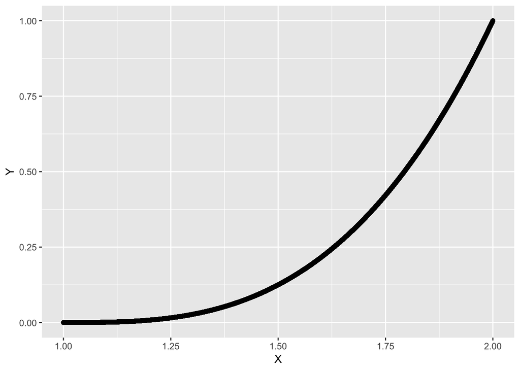

```r
CDF <- function(x){
  x^3 - 3*x^2 + 3*x -1
}
X = seq(1,2,.00001)
Y = CDF(X)
dat <- data.frame(X, Y)
ggplot(dat, aes(x=X, y=Y)) + geom_point()
```

# 5. Chapter 18, Exercise 14.

14. Consider the continuous random variable X with pdf given by: fX (x) = exp (−x) − ∞ < x < ∞. (1 + exp (−x))2 X is said to have a standard logistic distribution. Find the cdf for this random variable. Show how to simulate a rv with this cdf using the inversion method.

$$PDF = \frac{e^{-x}}{(1 + e^{-x})^2}$$

$$CDF = \int_{-\infty}^x \frac{e^{-x}}{(1 + e^{-x})^2} dx$$

Let $u = (1 + e^{-x})dx$, then $du = -e^{-x}dx$

$$CDF = -\int_{-\infty}^x \frac{1}{u^2} du = - \left[ \frac{u^{-1}}{-1} \right]_{x = - \infty} ^x = \left[ \frac{u^{-1}}{1} \right]_{x = - \infty} ^x = \left[ \frac {1}{u} \right]_{x = - \infty} ^x = \frac{1}{1 + e^{-x}}$$

Finding the inverse:
$$x = \frac{1}{1 + e^{-y}} \iff \frac{1}{x} = 1 + e^{-y} \iff \frac{1}{x} - 1 = e^{-y}$$

$$log\left(\frac{1}{x} - 1 \right) = -y$$

$$f^{-1} = -log \left(\frac{1}{x} - 1 \right)$$

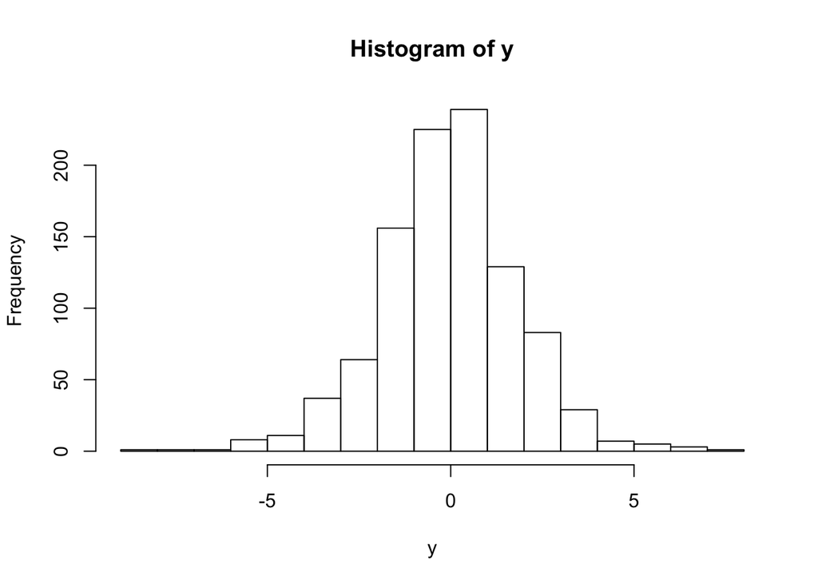

```r
f_inv <- function(x){
  -log(1/x -1)
}
u <- runif(1000)
y <- f_inv(u)
hist(y)
```

# 6. (GRAD ONLY) Chapter 18, Exercise 17.

17. The continuous random variable X has the following probability density function (pdf), for some positive constant c,
    $$f(x) = \frac{3}{(1 + x)^3}$$
    f(x) = 3 for 0 ≤ x ≤ c. (1 + x)3

## (a).

Prove that c = √3 − 1.
$$\int_{x=0} ^c \frac{3}{(1 + x)^3}dx = 1$$

Let $u = (1+x)$ and $du = 1dx$ so:
$$\iff \int_{x=0} ^c \frac{3}{u^3}du = 1$$
$$\iff \int_{u=1} ^{1 + c} 3u^{-3}du = 1$$
$$\iff \frac{-3}{2} \left[ u^{-2} \right]_{u=1} ^{1 + c} = 1$$
$$\iff \frac{-3}{2} \left[ \frac{1}{(1+c)^{2}} - \frac{1}{1^2} \right] = 1$$
$$\iff \frac{1}{(1+c)^{2}} - 1 = \frac{-2}{3}$$
$$\iff \frac{1}{(1+c)^{2}} = \frac{1}{3}$$
$$\iff (1+c)^{2} = 3$$
$$\iff 1+c = \pm \sqrt {3}$$
$$\iff c = \pm \sqrt {3} - 1$$

Since c is > 0 by definition:
$$c = \sqrt {3} - 1$$

## (b).

What is EX? (Hint:EX=E(X+1)−1.)
$$\mathop{\mathbb{E}} [X] = \mathop{\mathbb{E}} [X+1] - 1 = 3 \int_{x=0} ^ {\sqrt {3} - 1} \frac{x+1}{(x+1)^3}dx-1$$
$$= 3 \int_{x=0} ^ {\sqrt {3} - 1} \frac{1}{(x+1)^2}dx-1$$

Let $u = (1+x)$ and $du = 1dx$ so:
$$=3 \int_{x=0} ^ {\sqrt {3} - 1} \frac{1}{u^2}du -1 = 3 \int_{x=0} ^ {\sqrt {3} - 1} u^{-2}du -1$$
$$= -3 \left[u^{-1} \right]_{u=1} ^ {\sqrt {3}} -1 = -3\left[\frac{1}{\sqrt 3} - 1 \right] -1 = \frac{-3}{\sqrt {3}} + 2$$

## (c).

What is Var X ? (Hint: start with E(X + 1)2 .)
$$\mathop{\mathbb{E}} [(X + 1)^2] = \mathop{\mathbb{E}} [X^2 + 2X+1] = \mathop{\mathbb{E}} [X^2] + 2*\mathop{\mathbb{E}}[X]+1]$$

$$\mathop{\mathbb{E}} [(X + 1)^2] = 3 \int_{x=0} ^ {\sqrt {3} - 1} \frac{(x+1)^2}{(x+1)^3}dx = 3 \int_{x=0} ^ {\sqrt {3} - 1} \frac{1}{(x+1)}dx$$

Let $u = x + 1$ so $du = 1dx$ :

$$= 3 \int_{x=0} ^ {\sqrt {3} - 1} \frac{1}{u}dx = 3 [log(u)]_{u=1} ^ {\sqrt{3}} = 3log(\sqrt{3})$$

So

$$\mathop{\mathbb{E}}[X^2] = \mathop{\mathbb{E}} [(X + 1)^2] - 2\mathop{\mathbb{E}}[X] - 1$$

$$Var[X] = \mathop{\mathbb{E}}[X^2] - (\mathop{\mathbb{E}}[X])^2$$
Substituting:
$$Var[X] = \mathop{\mathbb{E}} [(X + 1)^2] - 2\mathop{\mathbb{E}}[X] - 1 - (\mathop{\mathbb{E}}[X])^2$$

$$\iff Var[X] = 3log(\sqrt{3}) - 2\left(\frac{-3}{\sqrt {3}} + 2\right) - 1 - \left(\frac{-3}{\sqrt {3}} + 2\right)^2$$
$$\iff Var[X] = 3log(\sqrt3) + \left(\frac{6}{\sqrt {3}} - 4\right) - 1 - \left(\frac{9}{3} - \frac{-12}{\sqrt{3}} + 4\right)$$

$$\iff Var[X] = 3log(\sqrt{3}) + \frac{18}{\sqrt{3}} - 12$$

## (d).

Using the inversion method, write a function that simulates X.

$$CDF = \int_{x=0} ^{x} \frac{3}{(1 + x)^3} dx$$

Let $u = (1+x)$ so $du = 1 dx$
$$3\int_{u=1} ^{x+1} \frac{1}{u^3} du = \frac{-3}{2}\left[\frac{1}{u^2}\right]_{u=1} ^{x+1} = \frac{-3}{2}\left[\frac{1}{(x+1)^2} - 1\right]$$

Now to find the inverse
$$x = \frac{-3}{2}\left[\frac{1}{(y+1)^2} - 1\right]$$
$$\iff \frac{-2x + 3}{3} = \frac{1}{(y+1)^2}$$

$$\iff \frac{3}{-2x + 3} = (y+1)^2$$
$$\iff \pm \sqrt{\frac{3}{-2x + 3} }= y+1$$

$$\iff f^{-1} = + \sqrt{\frac{3}{-2x + 3} }-1$$

Only positive, because the support is positive

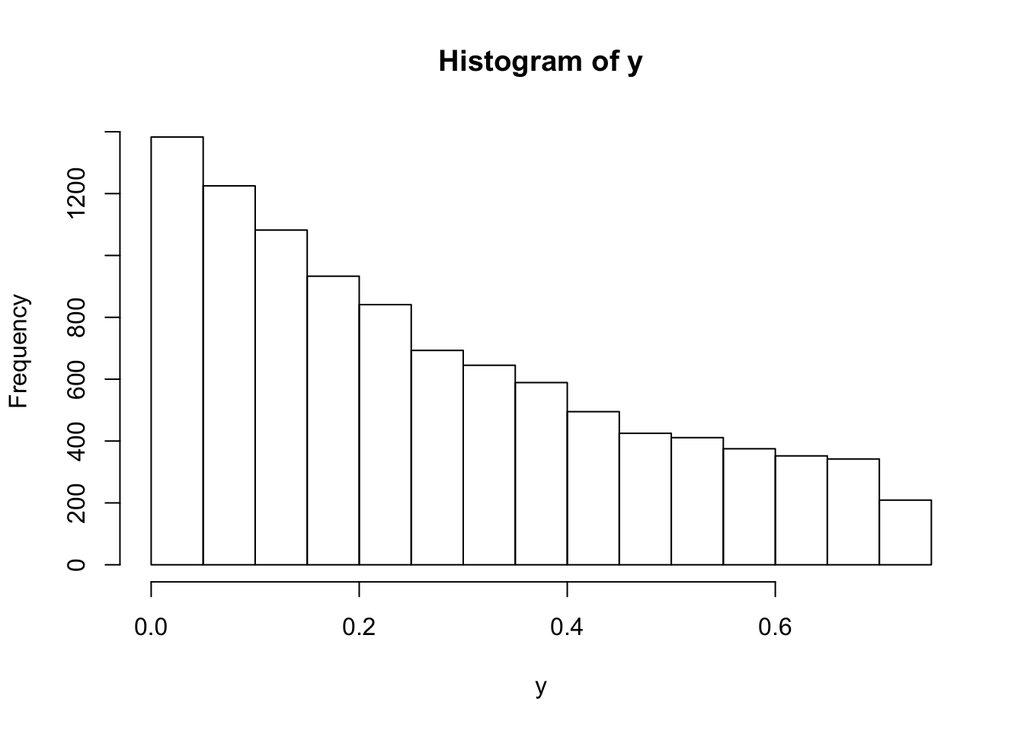

```r
inverse <- function(x){
  sqrt(3/(-2*x + 3)) - 1
}
u <- runif(10000)
y <- inverse(u)
hist(y)
```

```r
c(mean(y),var(y))
```

```
## [1] 0.26752641 0.04074427
```

```r
mean_theory <- -3/sqrt(3) + 2
var_theory <- 3*log(sqrt(3)) + 18/sqrt(3) - 12
c(mean_theory, var_theory)
```

```
## [1] 0.26794919 0.04022328
```

# 7. (GRAD ONLY) Chapter 18, Exercise 18.

18. The Cauchy distribution with parameter α has pdf
    $$f(x) = \frac{\alpha}{\pi(\alpha^2 + x^2)}$$
    fX (x) = α − ∞ < x < ∞. π(α2 +x2) Write a program to simulate from the Cauchy distribution using the inversion method.
    $$CDF = \int _{-\infty} ^x \frac{\alpha}{\pi(\alpha^2 + x^2)} dx = \frac{1}{\pi}\int _{-\infty} ^x \frac{\alpha * \frac{1}{\alpha^2}}{(\alpha^2 + x^2)* \frac{1}{\alpha^2}} dx = \frac{1}{\pi}\int _{-\infty} ^x \frac{\frac{1}{\alpha}}{1 + \left(\frac{x}{\alpha}\right)^2} dx$$

Let $u = \frac{x}{\alpha}$ so $du = \frac{1}{\alpha}dx$

$$= \frac{1}{\pi}\int _{x= -\infty} ^x \frac{1}{1 + u^2} dx = \frac{1}{\pi} arctan(u) = \frac{1}{\pi} arctan \left(\frac{x}{\alpha}\right)$$

Inverse
$$x = \frac{1}{\pi} arctan \left(\frac{y}{\alpha}\right)$$
$$\pi x = arctan \left(\frac{y}{\alpha}\right)$$
$$f^{-1} = \alpha tan(\pi x)$$

```r
Cauchy_inv <- function(alpha, x){
  alpha * tan(pi*x)
}
```

Now consider using a Cauchy envelope to generate a standard normal random variable using the rejection method. Find the values for α and the scaling constant k that minimise the probability of rejection. Write an R program to implement the algorithm.

$$k^* = sup_x \frac{f(x)}{h(x)} = sup_x \frac{\frac{e^{-x^2/2}}{\sqrt{2\pi}}}{\frac{\alpha}{\pi(\alpha^2 + x^2)}} = sup_x \frac{e^{-x^2/2}}{\sqrt{2\pi}}*\frac{\pi(\alpha^2 + x^2)}{\alpha}$$

To maximize we need to take the derivative and set that equal to 0 (using product rule):
$$\frac{d}{dx}\frac{e^{-x^2/2}}{\sqrt{2\pi}}*\frac{\pi(\alpha^2 + x^2)}{\alpha} = \frac{\pi}{\sqrt{2\pi}*\alpha}*\left(e^{-x^2/2}*(-x)*(\alpha^2 + x^2) + e^{-x^2/2}*2x\right) = 0$$

$$e^{-x^2/2}\left(-\alpha^2x - x^3 + 2x \right)= 0$$

$$e^{-x^2/2} = 0$$

Not a maximum because the log(0) is negative infinity

$$-\alpha^2x - x^3 + 2x = 0 \iff x(-\alpha^2 - x^2 + 2) = 0$$

x = 0 is a possible sup

$$-\alpha^2 - x^2 + 2 = 0 \iff x^2 = 2 - \alpha^2 \iff x = \pm \sqrt{2-\alpha^2}$$

With x = 0
$$k^*_1 = \frac{1}{\sqrt{2\pi}}*\frac{\pi(\alpha^2)}{\alpha} = \frac{\pi\alpha}{\sqrt{2\pi}}$$

With $x = \sqrt{2-\alpha^2}$ (Note, because of squaring, the negatve version will be the same).
$$k^*_2 = \frac{e^{-1+\alpha/2}}{\sqrt{2\pi}}*\frac{\pi(\alpha^2 + 2 - \alpha^2)}{\alpha} = \frac{e^{-1+\alpha/2}}{\sqrt{2\pi}}*\frac{2\pi}{\alpha}$$

Let’s define all two k* possibilities

```r
#kstar1 <- pi*alpha/sqrt(2*pi)
#kstar2 <- exp(-1+alpha/2)/sqrt(2*pi)*pi*(2)/alpha


norm.sim1 <- function(alpha) {
  reject_count <- 0

f <- function(x) {1/sqrt(2*pi)*exp(-X^2/2)}
h <- function(x) {alpha/(pi*(alpha*2+x^2))}
kstar1 <- pi*alpha/sqrt(2*pi)
while (TRUE) {
X <- alpha * tan(pi*runif(1))
Y <- runif(1, 0, kstar1*h(X))
if (Y < f(X)) return(c(X, reject_count))
else reject_count <- reject_count + 1
}
}

norm.sim1(alpha = 1)
```

```
## [1] 1.983718 0.000000
```

```r
norm.sim2 <- function(alpha) {
  reject_count <- 0

f <- function(x) {1/sqrt(2*pi)*exp(-X^2/2)}
h <- function(x) {alpha/(pi*(alpha*2+x^2))}
kstar2 <- 1/sqrt(2*pi)*pi*(alpha^2+1)/alpha
while (TRUE) {
X <- alpha * tan(pi*runif(1))
Y <- runif(1, 0, kstar2*h(X))
if (Y < f(X)) return(c(X, reject_count))
else reject_count <- reject_count + 1
}
}
norm.sim2(alpha = 1)
```

```
## [1] 0.3636677 0.0000000
```

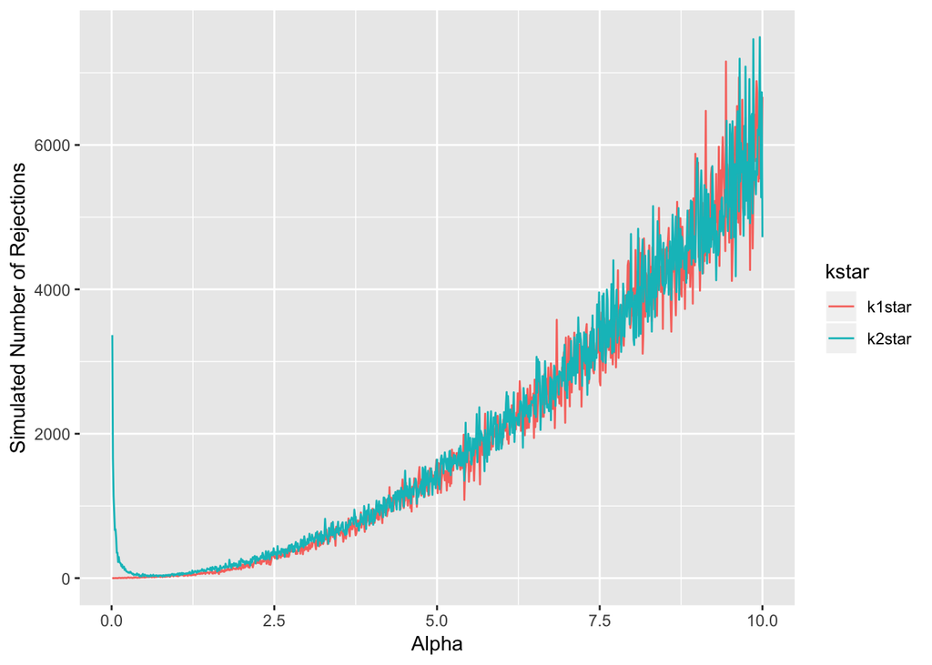

```r
Rejection_sum1 <- function(alp, N){
output <- replicate(norm.sim1(alpha = alp), n=N) %>% t() %>% as.tibble()
sum1 <-sum(output$V2)
return(sum1)
}

Rejection_sum2 <- function(alp, N){
output <- replicate(norm.sim2(alpha = alp), n=N) %>% t() %>% as.tibble()
sum2 <-sum(output$V2)
return(sum2)
}

alpha_seq <- seq(.01, 10, .01)

X = rep(alpha_seq, 2)

Y1 <- map_dbl(alpha_seq, function(x) Rejection_sum1(alp = x, N=100))
Y2 <- map_dbl(alpha_seq, function(x) Rejection_sum2(alp = x, N=100))
Y<- c(Y1, Y2)

kstar <- c(rep("k1star", length(alpha_seq)), rep("k2star", length(alpha_seq)))

data <- data.frame(X, Y, kstar)
ggplot(data, aes(x=X, y = Y, col=kstar)) + geom_line() + xlab("Alpha") + ylab("Simulated Number of Rejections")
```

From my beautiful graph, it looks like my k1star
$$k^*_1 = \frac{\pi\alpha}{\sqrt{2\pi}}$$
tends to perfom a little better when alpha is small (which seems typical for a Cauchy distribution). Also, the optimal alpha appears to be less than 1. So I will do this simulation again with smaller alpha values

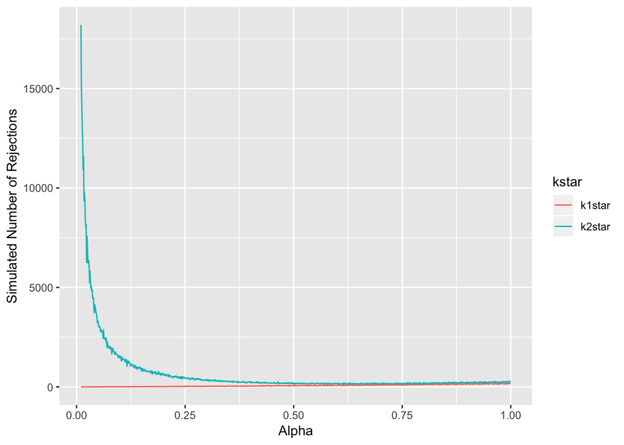

```r
alpha_seq <- seq(.01, 1, .001)
X = rep(alpha_seq, 2)

Y1 <- map_dbl(alpha_seq, function(x) Rejection_sum1(alp = x, N=500))
Y2 <- map_dbl(alpha_seq, function(x) Rejection_sum2(alp = x, N=500))
Y<- c(Y1, Y2)

kstar <- c(rep("k1star", length(alpha_seq)), rep("k2star", length(alpha_seq)))

data <- data.frame(X, Y, kstar)
ggplot(data, aes(x=X, y = Y, col=kstar)) + geom_line() + xlab("Alpha") + ylab("Simulated Number of Rejections")
```

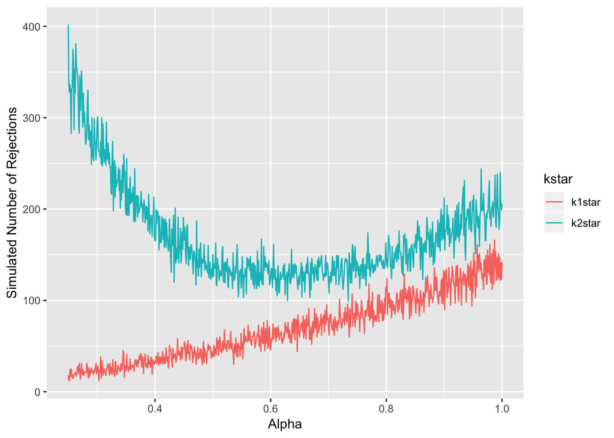

```r
alpha_seq <- seq(.25, 1, .001)
X = rep(alpha_seq, 2)

Y1 <- map_dbl(alpha_seq, function(x) Rejection_sum1(alp = x, N=400))
Y2 <- map_dbl(alpha_seq, function(x) Rejection_sum2(alp = x, N=400))
Y<- c(Y1, Y2)

kstar <- c(rep("k1star", length(alpha_seq)), rep("k2star", length(alpha_seq)))

data <- data.frame(X, Y, kstar)
ggplot(data, aes(x=X, y = Y, col=kstar)) + geom_line() + xlab("Alpha") + ylab("Simulated Number of Rejections")
```

Now we can more clearly see k1star winning so I will look only at k1star

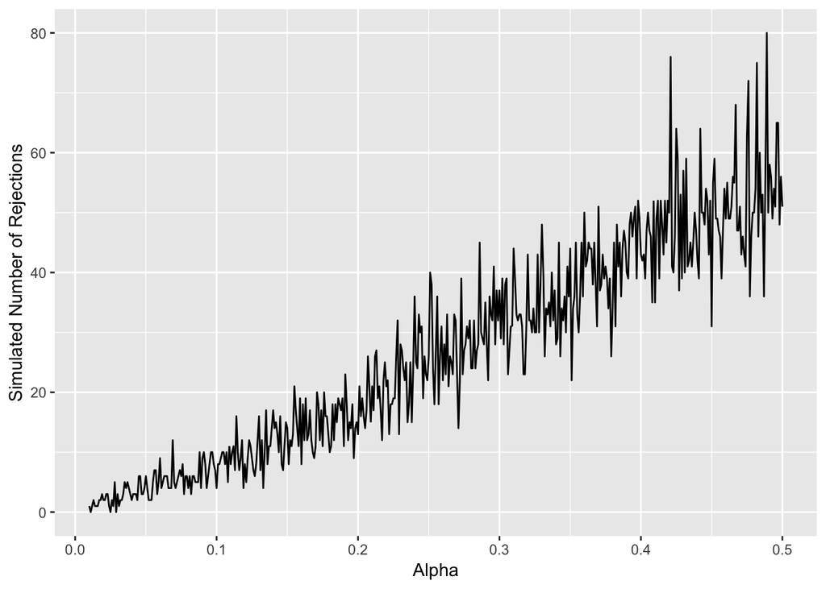

```r
alpha_seq <- seq(0.01, .5, .001)
X = alpha_seq

Y1 <- map_dbl(alpha_seq, function(x) Rejection_sum1(alp = x, N=500))
#Y2 <- map_dbl(alpha_seq, function(x) Rejection_sum2(alp = x, N=500))
Y<- c(Y1, Y2)

kstar <- c(rep("k1star", length(alpha_seq)), rep("k2star", length(alpha_seq)))

data <- data.frame(X, Y1)
ggplot(data, aes(x=X, y = Y1)) + geom_line() + xlab("Alpha") + ylab("Simulated Number of Rejections")
```

So I think the best combination for lowest rejection is k1star, and alpha = 0.01 (Since 0 seems to be giving me an error).